# Multi-ancestry PRS practical

Gibran Hemani

## Background

A GWAS has been conducted for an adiposity-related trait in 5 populations:

- European (EUR), n = 100,000
- African (AFR), n = 30,000
- East Asian (EAS), n = 30,000
- South Asian (SAS), n = 30,000
- Admixed American (AMR), n = 30,000

As you can see the sample sizes are different across populations. The file `gwas_res.csv` has a subset of the results from this GWAS, retaining only the results that were GWAS significant (p < 5e-8) in the EUR population. Here, the EUR population is the **discovery** population. The SNPs identified as GWAS significant in the discovery population are known as the **discovery SNPs**.

In addition, the **discovery SNPs** were used to calculate the polygenic risk scores (PRS) in a small independent sample from each population. The file `individual_values.csv` contains the PRS and other phenotypes for each individual in each population.

## Objectives

- Understand the two datasets
- Look for differences in the effect sizes across populations
- Examine why differences in effect sizes might arise
- Investigate the performance of the PRS across populations

## Setup

Load relevant libraries

```r
library(ggplot2)
library(dplyr)
```

Read in the relevant data. We are reading the files directly from github here but you can also download the files and read them locally if you prefer

```r
gwas_res <- read.csv(url("https://raw.githubusercontent.com/MRCIEU/multi-ancestry-prs-practical/refs/heads/main/gwas_res.csv"))
individual_values <- read.csv(url("https://raw.githubusercontent.com/MRCIEU/multi-ancestry-prs-practical/refs/heads/main/individual_values.csv"))
```

## 1. Simple GWAS hits comparisons

Have a look at the GWAS summary data

```r
str(gwas_res)
```

```
## 'data.frame':    851 obs. of  25 variables:
##  $ X       : int  1 2 3 4 5 6 7 8 9 10 ...
##  $ snp     : chr  "rs201284055" "rs241276" "rs61764903" "rs6660626" ...
##  $ ea      : chr  "G" "T" "C" "G" ...
##  $ oa      : chr  "A" "C" "T" "C" ...
##  $ af_AFR  : num  0.0219 0.0582 0.0318 0.0151 0.0144 ...
##  $ bhat_AFR: num  -0.0451 -0.0593 0.0876 0.0653 -0.1533 ...
##  $ se_AFR  : num  0.0279 0.0174 0.0233 0.0334 0.0343 ...
##  $ pval_AFR: num  1.06e-01 6.71e-04 1.66e-04 5.08e-02 7.79e-06 ...
##  $ af_AMR  : num  0.1513 0.2925 0.0259 0.1023 0.3314 ...
##  $ bhat_AMR: num  -0.0414 -0.0302 0.0358 0.0312 -0.1909 ...
##  $ se_AMR  : num  0.01139 0.00897 0.02568 0.01347 0.0086 ...
##  $ pval_AMR: num  2.81e-04 7.75e-04 1.64e-01 2.05e-02 3.34e-108 ...
##  $ af_EAS  : num  0.3185 0.1121 0.0308 0.1141 0.4147 ...
##  $ bhat_EAS: num  -0.0486 -0.0474 0.1057 0.0697 -0.1861 ...
##  $ se_EAS  : num  0.00876 0.01294 0.02364 0.01284 0.00821 ...
##  $ pval_EAS: num  2.91e-08 2.50e-04 7.79e-06 5.61e-08 1.03e-112 ...
##  $ af_EUR  : num  0.1392 0.4861 0.0706 0.1769 0.3012 ...
##  $ bhat_EUR: num  -0.0482 -0.0447 0.0669 0.0342 -0.1885 ...
##  $ se_EUR  : num  0.00646 0.00447 0.00873 0.00586 0.00484 ...
##  $ pval_EUR: num  8.17e-14 1.55e-23 1.79e-14 5.42e-09 0.00 ...
##  $ af_SAS  : num  0.2546 0.2832 0.0562 0.2147 0.3712 ...
##  $ bhat_SAS: num  -0.0458 -0.0363 0.0669 0.0652 -0.1815 ...
##  $ se_SAS  : num  0.00937 0.00906 0.01772 0.00994 0.00838 ...
##  $ pval_SAS: num  1.02e-06 6.06e-05 1.61e-04 5.50e-11 3.17e-103 ...
##  $ Qpval   : num  0.988 0.454 0.31 0.013 0.788 ...
```

**QUESTION 1**: What are the rows and columns in the dataset and what do they represent?

Let’s see which SNPs are significant in Europeans

```r
table(gwas_res$pval_EUR < 5e-8)
```

```
##
## TRUE
##  851
```

**QUESTION 2**: How many SNPs are significant in each of the other 4 populations?

**QUESTION 3**: What factors might be driving the results that you have found?

Let’s look at the allele frequencies of the significant SNPs, for example comparing AFR and EUR:

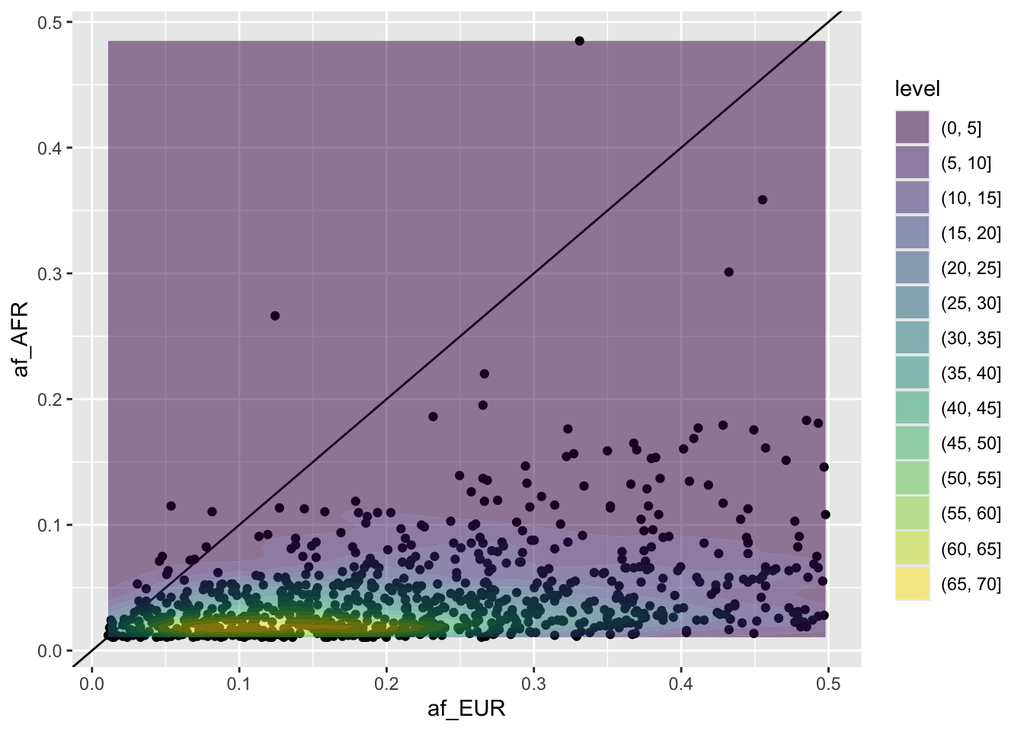

```r
ggplot(gwas_res, aes(x=af_EUR, y=af_AFR)) +
    geom_point() +
    geom_abline() +
    geom_density_2d_filled(alpha=0.5)
```

**QUESTION 4**: In which population are the SNPs more common? Does this match what you expected based on the p-value comparison?

## 2. Comparing effect sizes across populations

Let’s compare the effect sizes now. Subset the data to only include the effect estimates, then plot them against each other:

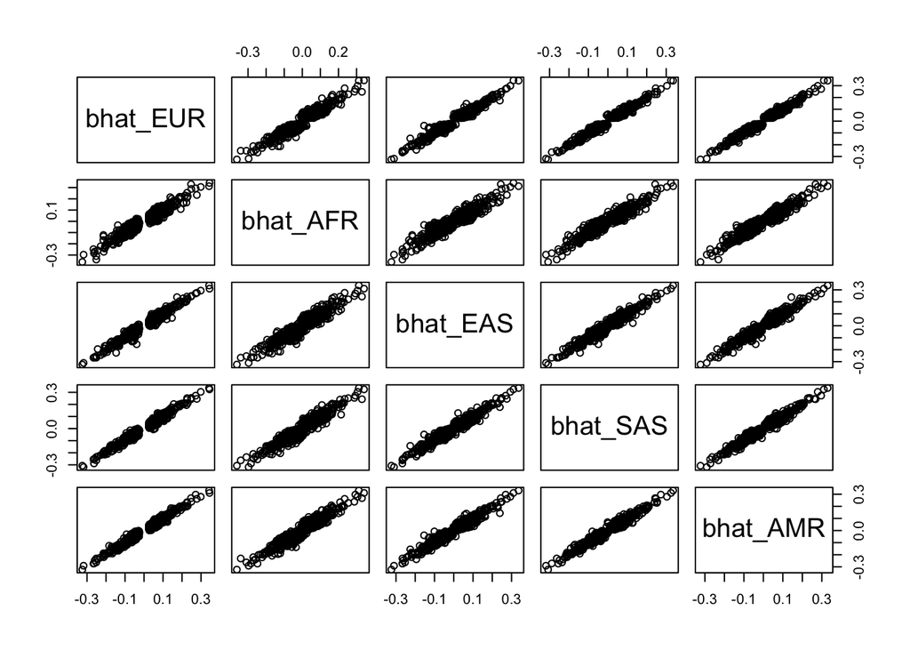

```r
subset(gwas_res, select = c("bhat_EUR", "bhat_AFR", "bhat_EAS", "bhat_SAS", "bhat_AMR")) |> pairs()
```

**QUESTION 5**: What do you observe from the plot? Does this match what you expected based on the p-value comparison?

## 3. Accounting for differences in power

Instead of looking at p-values to determine if the associations are consistent across populations, we could examine whether the effects are consistent. This can be achieved using a Cochran’s Q heterogeneity test.

$$Q = \sum_{i=1}^k w_i (\hat{\beta}_i - \hat{\beta})^2$$

where $w_i = 1 / \text{SE}(\hat{\beta}_i)^2$ and $\hat{\beta}$ is the overall effect estimate. Essentially, this test asks if the confidence intervals of the effect estimates overlap. If they overlap, we would conclude that the effects are statistically consistent across populations.

The `Qpval` column gives us a p-value for the Cochran’s Q test statistic for each SNP. We can examine if any of these are significant for heterogeneity after multiple testing.

```r
table(gwas_res$Qpval < 0.05 / nrow(gwas_res))
```

```
##
## FALSE  TRUE
##   850     1
```

```r
min(gwas_res$Qpval)
```

```
## [1] 3.116962e-08
```

Let’s examine the effect estimates for two SNPs, one that has a significant Qpval and one that doesn’t. First the one that is not significant:

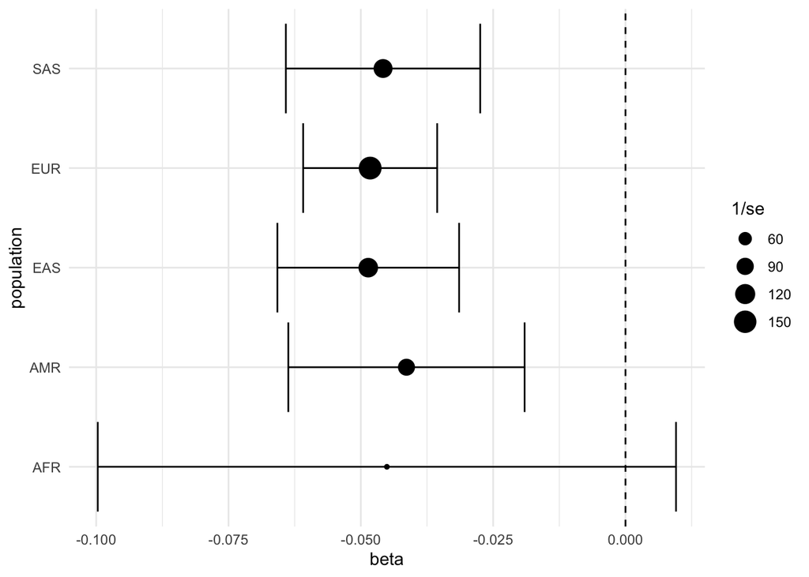

```r
plot_effect_size <- function(gwas_res, i) {
    dat <- data.frame(
        population = c("EUR", "AFR", "EAS", "SAS", "AMR"),
        beta = c(gwas_res$bhat_EUR[i], gwas_res$bhat_AFR[i], gwas_res$bhat_EAS[i], gwas_res$bhat_SAS[i], gwas_res$bhat_AMR[i]),
        se = c(gwas_res$se_EUR[i], gwas_res$se_AFR[i], gwas_res$se_EAS[i], gwas_res$se_SAS[i], gwas_res$se_AMR[i])
    )
    ggplot(dat, aes(x=beta, y=population)) +
        geom_point(aes(size=1/se)) +
        geom_errorbarh(aes(xmin=beta - 1.96 * se, xmax=beta + 1.96 * se)) +
        geom_vline(xintercept=0, linetype="dashed") +
        theme_minimal()
}
plot_effect_size(gwas_res, 1)
```

We can see that this SNP has slightly different effect estimates across populations, but the confidence intervals overlap quite substantially, suggesting that the true causal effect of the SNPs is relatively consistent across populations.

**QUESTION 6**: Use the `plot_effect_size` function above to now plot the effect estimates for the SNP that has strong evidence of heterogeneity. Which population appears to be driving the heterogeneity?

## 4. Examining why differences in effect sizes might arise

The SNP that you identified as having strong evidence of heterogeneity is available in another dataset, along with the adiposity phenotype, and a potential interacting variable (`alcohol` intake). Could a genotype x environment interaction explain the result, where the environmental variable here is alcohol consumption?

Let’s load the data:

```r
str(individual_values)
```

```
## 'data.frame':    2504 obs. of  9 variables:
##  $ X         : int  1 2 3 4 5 6 7 8 9 10 ...
##  $ id        : chr  "HG01879" "HG01880" "HG01882" "HG01883" ...
##  $ true_score: num  0.03864 0.10592 0.12707 0.00951 0.09477 ...
##  $ eur_score : num  0.86 1.194 0.985 0.782 1.098 ...
##  $ rs58903867: int  2 1 0 1 1 1 1 1 2 2 ...
##  $ pop       : chr  "AFR" "AFR" "AFR" "AFR" ...
##  $ alcohol   : int  1 1 1 1 0 1 1 1 1 1 ...
##  $ e         : num  -0.11092 0.0325 -0.00303 0.03093 -0.03986 ...
##  $ phen      : num  -0.0323 0.1584 0.124 0.0604 0.0549 ...
```

**QUESTION 7**: Describe this dataset - what are the columns and rows, what do they represent?

**QUESTION 8**: If this were real data (it’s not in this case, it’s all simulated!), would you handle it differently to the data in `gwas_res`? Why?

Let’s look at whether the heterogeneity effect by population still exists here:

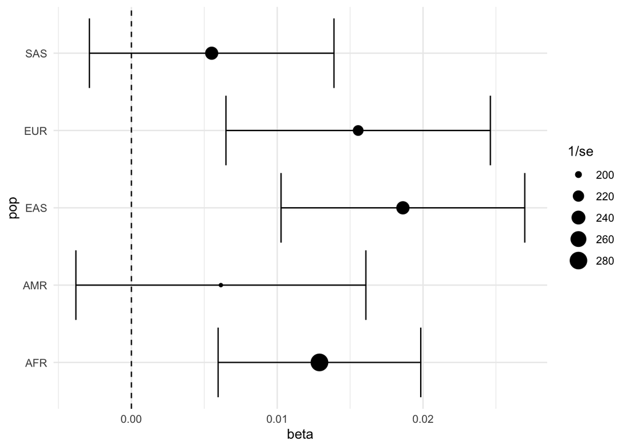

```r
# For each population, fit a linear model
effect_estimates <- lapply(c("EUR", "AFR", "EAS", "SAS", "AMR"), \(p) {
    # The linear model is estimating the effect of the SNP on phen in that subgroup
    mod <- summary(lm(phen ~ rs58903867, data=subset(individual_values, pop == p)))
    # Save the effect estimate and standard error
    data.frame(pop=p, beta=mod$coefficients[2,1], se=mod$coefficients[2,2])
}) %>% bind_rows()

# Plot the effect estimates in a forest plot
ggplot(effect_estimates, aes(x=beta, y=pop)) +
    geom_point(aes(size=1/se)) +
    geom_errorbarh(aes(xmin=beta - 1.96 * se, xmax=beta + 1.96 * se)) +
    geom_vline(xintercept=0, linetype="dashed") +
    theme_minimal()
```

**QUESTION 9**: Does this replicate the evidence for heterogeneity that you observed in the GWAS summary data?

Instead of partitioning the samples by ancestry, let’s now partition the samples by alcohol consumption instead to see if that is the relevant mechanism. First examine if alcohol consumption varies by population:

```r
individual_values %>% group_by(pop) %>% summarise(mean_alcohol=mean(alcohol))
```

```
## # A tibble: 5 × 2
##   pop   mean_alcohol
##   <chr>        <dbl>
## 1 AFR          0.793
## 2 AMR          0.793
## 3 EAS          0.806
## 4 EUR          0.839
## 5 SAS          0.108
```

It looks like alcohol consumption is much lower in South Asians. Let’s now examine the effect estimates for the SNP by alcohol consumption:

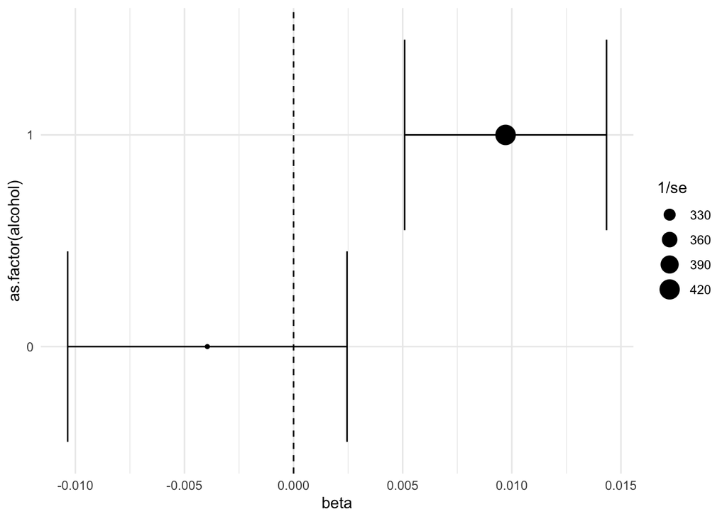

```r
# For each alcohol value, fit a linear model
effect_estimates <- lapply(c(0, 1), \(p) {
    # The linear model is estimating the effect of the SNP on phen in that subgroup
    mod <- summary(lm(phen ~ rs58903867, data=subset(individual_values, alcohol == p)))
    # Save the effect estimate and standard error
    data.frame(alcohol=p, beta=mod$coefficients[2,1], se=mod$coefficients[2,2])
}) %>% bind_rows()

# Plot the effect estimates in a forest plot
ggplot(effect_estimates, aes(x=beta, y=as.factor(alcohol))) +
    geom_point(aes(size=1/se)) +
    geom_errorbarh(aes(xmin=beta - 1.96 * se, xmax=beta + 1.96 * se)) +
    geom_vline(xintercept=0, linetype="dashed") +
    theme_minimal()
```

**QUESTION 10**: Propose a mechanism that would explain the results you have seen.

**QUESTION 11**: How could the linear model be improved to reduce the possibility of bias?

## 5. Investigating the performance of the PRS across populations

Now let’s examine the polygenic risk scores across populations. In the `individual_values.csv` file, this is simulated data, and we have the true polygenic scores that explain all the heritability of the trait in the `true_score` column. Let’s look at the distribution of the true scores across populations:

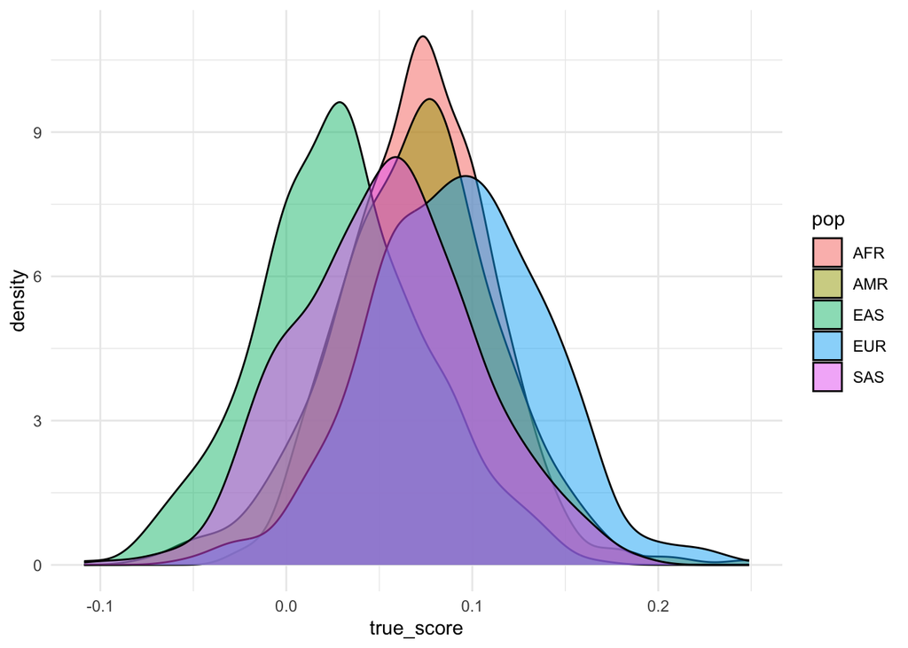

```r
ggplot(individual_values, aes(x=true_score, fill=pop)) +
    geom_density(alpha=0.5) +
    theme_minimal()
```

The true polygenic scores have very similar distributions across populations, with some evidence that the mean score is slightly lower in East Asians compared to other populations.

**QUESTION 12** The estimated PRS is in the column `dat$eur_score`. Plot the distributions of the estimated PRS across populations. Do you see any differences?

We can also evaluate the prediction accuracy of the PRS in each population. This is how to do it for the EUR population:

```r
cor(individual_values$eur_score[individual_values$pop == "EUR"], individual_values$phen[individual_values$pop == "EUR"])^2
```

```
## [1] 0.2607672
```

**QUESTION 13** Which population has the highest prediction accuracy using the EUR PRS? Why do you think this is the case?

**QUESTION 14** What could be done to improve the prediction accuracy in the other populations?